# Self-Driving Car Engineer Nanodegree

## Project: Build a Traffic Sign Recognition Classifier

## Author: Felipe Pamboukian

In this notebook, a traffic sign classifier is implemented using Convolucional Neural Network based on LeNet architecture, German Traffic Sign Dataset is used to train the model.

## Step 0: Load The Data

```python
import  cv2
import numpy as np
import pandas as pd
import matplotlib.pyplot as plt
import matplotlib.image as mpimg
from sklearn.utils import shuffle
import tensorflow as tf
from tensorflow.contrib.layers import flatten
```

```python
# Load pickled data
import pickle

training_file = '../data/train.p'
validation_file= '../data/valid.p'
testing_file = '../data/test.p'

with open(training_file, mode='rb') as f:
    train = pickle.load(f)
with open(validation_file, mode='rb') as f:
    valid = pickle.load(f)
with open(testing_file, mode='rb') as f:
    test = pickle.load(f)

X_train, y_train = train['features'], train['labels']
X_valid, y_valid = valid['features'], valid['labels']
X_test, y_test = test['features'], test['labels']
```

## Step 1: Dataset Summary & Exploration

The pickled data is a dictionary with 4 key/value pairs:

- `'features'` is a 4D array containing raw pixel data of the traffic sign images, (num examples, width, height, channels).
- `'labels'` is a 1D array containing the label/class id of the traffic sign. The file `signnames.csv` contains id -> name mappings for each id.
- `'sizes'` is a list containing tuples, (width, height) representing the original width and height the image.
- `'coords'` is a list containing tuples, (x1, y1, x2, y2) representing coordinates of a bounding box around the sign in the image. **THESE COORDINATES ASSUME THE ORIGINAL IMAGE. THE PICKLED DATA CONTAINS RESIZED VERSIONS (32 by 32) OF THESE IMAGES**

### Basic Summary of the Dataset

```python
n_train = len(X_train)
n_validation = len(X_valid)
n_test = len(X_test)

image_shape = X_train[0].shape

classes = pd.DataFrame(y_train)[0].unique()
n_classes = len(classes)

print("Number of training examples =", n_train)
print("Number of testing examples =", n_test)
print("Image data shape =", image_shape)
print("Number of classes =", n_classes)
```

```
Number of training examples = 34799
Number of testing examples = 12630
Image data shape = (32, 32, 3)
Number of classes = 43
```

### Visualization of the dataset

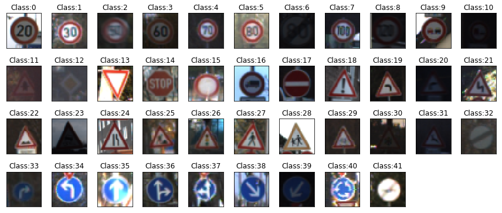

```python
### Data exploration visualization code goes here.
### Feel free to use as many code cells as needed.
import matplotlib.cm as cm
# Visualizations will be shown in the notebook.
%matplotlib inline

def plot_each_class(x, y, classes):
    fig = plt.figure(figsize=(12,19))
    for j in range(len(classes)-1):
        ax = fig.add_subplot(15, 11, j+1)
        index = np.random.choice(np.where(y==j)[0])
        if x.shape[3] == 1:
            ax.imshow(x[index], cmap='gray')
        else:
            ax.imshow(x[index])
        plt.xticks(np.array([]))
        plt.yticks(np.array([]))
        plt.title('Class:'+str(j))
        plt.tight_layout()

plot_each_class(X_train, y_train, classes)
```

#### Showing number of samples for each class

[figure not shown]

```python
class_arr= []
samples_arr=[]

for class_n in range(n_classes):
    class_indices = np.where(y_train == class_n)
    n_samples = len(class_indices[0])
    class_arr.append(class_n)
    samples_arr.append(n_samples)

#plt.hist(y_train,bins=43)
plt.bar( class_arr, samples_arr,align='center', alpha=0.5)
plt.ylabel('Classes')
plt.xlabel('No of Samples')
plt.title('Data Visualization')
plt.show()
```

## Step 2: Design and Test a Model Architecture

Design and implement a deep learning model that learns to recognize traffic signs. Train and test your model on the [German Traffic Sign Dataset](http://benchmark.ini.rub.de/?section=gtsrb&subsection=dataset).

### Pre-process the Data Set (normalization, grayscale, etc.)

```python
def preprocessing(imageset):
    new_shape = image_shape[0:2] + (3,)
    new_imageset = np.empty(shape=(len(imageset),) + new_shape, dtype=int)

    for i in range(0, len(imageset)):
        #gray_img = cv2.cvtColor(imageset[i], cv2.COLOR_RGB2GRAY)
        #norm_img = cv2.normalize(gray_img, np.zeros(image_shape[0:2]), 0, 255, cv2.NORM_MINMAX)
        norm_img = cv2.normalize(imageset[i], np.zeros(image_shape[0:2]), 0, 255, cv2.NORM_MINMAX)
        new_imageset[i] = np.reshape(norm_img, new_shape)

    return new_imageset

#X_train = preprocessing(X_train)
#X_valid = preprocessing(X_valid)
#X_test = preprocessing(X_test)
```

### Shuffle training dataset

```python
X_train, y_train = shuffle(X_train, y_train)
```

### Model Architecture

The model architecture is almost the same, I just modified to use color images and output to 43 classes.

```python
def LeNet(x, keep_prob):
 # Arguments used for tf.truncated_normal, randomly defines variables for the weights and biases for each layer
    mu = 0
    sigma = 0.1

    # Layer 1: Convolutional. Input = 32x32x3. Output = 28x28x6.
    conv1_W = tf.Variable(tf.truncated_normal(shape=(5, 5, 3, 6), mean = mu, stddev = sigma))
    conv1_b = tf.Variable(tf.zeros(6))
    conv1   = tf.nn.conv2d(x, conv1_W, strides=[1, 1, 1, 1], padding='VALID') + conv1_b
    # Activation.
    conv1 = tf.nn.relu(conv1)
    # Pooling. Input = 28x28x6. Output = 14x14x6.
    conv1 = tf.nn.max_pool(conv1, ksize=[1, 2, 2, 1], strides=[1, 2, 2, 1], padding='VALID')

    # Layer 2: Convolutional. Output = 10x10x16.
    conv2_W = tf.Variable(tf.truncated_normal(shape=(5, 5, 6, 16), mean = mu, stddev = sigma))
    conv2_b = tf.Variable(tf.zeros(16))
    conv2   = tf.nn.conv2d(conv1, conv2_W, strides=[1, 1, 1, 1], padding='VALID') + conv2_b
    # Activation.
    conv2 = tf.nn.relu(conv2)
    # Pooling. Input = 10x10x16. Output = 5x5x16.
    conv2 = tf.nn.max_pool(conv2, ksize=[1, 2, 2, 1], strides=[1, 2, 2, 1], padding='VALID')
    # Flatten. Input = 5x5x16. Output = 400.
    fc0   = flatten(conv2)
    fc0   = tf.nn.dropout(fc0, keep_prob=keep_prob)

    # Layer 3: Fully Connected. Input = 400. Output = 120.
    fc1_W = tf.Variable(tf.truncated_normal(shape=(400, 120), mean = mu, stddev = sigma))
    fc1_b = tf.Variable(tf.zeros(120))
    fc1   = tf.matmul(fc0, fc1_W) + fc1_b
    # Activation.
    fc1    = tf.nn.relu(fc1)

    # Layer 4: Fully Connected. Input = 120. Output = 84.
    fc2_W  = tf.Variable(tf.truncated_normal(shape=(120, 84), mean = mu, stddev = sigma))
    fc2_b  = tf.Variable(tf.zeros(84))
    fc2    = tf.matmul(fc1, fc2_W) + fc2_b
    # Activation.
    fc2    = tf.nn.relu(fc2)

    # Layer 5: Fully Connected. Input = 84. Output = 43.
    fc3_W  = tf.Variable(tf.truncated_normal(shape=(84, 43), mean = mu, stddev = sigma))
    fc3_b  = tf.Variable(tf.zeros(43))
    logits = tf.matmul(fc2, fc3_W) + fc3_b

    return logits
```

### Train, Validate and Test the Model

A validation set can be used to assess how well the model is performing. A low accuracy on the training and validation sets imply underfitting. A high accuracy on the training set but low accuracy on the validation set implies overfitting.

```python
### Train your model here.
### Calculate and report the accuracy on the training and validation set.
### Once a final model architecture is selected,
### the accuracy on the test set should be calculated and reported as well.
### Feel free to use as many code cells as needed.

x = tf.placeholder(tf.float32, (None, 32, 32, 3))
y = tf.placeholder(tf.int32, (None))
one_hot_y = tf.one_hot(y, 43)

EPOCHS = 50
BATCH_SIZE = 128
rate = 0.0009
KEEP_PROB = 0.5

keep_prob = tf.placeholder(tf.float32)

logits = LeNet(x, keep_prob)
cross_entropy = tf.nn.softmax_cross_entropy_with_logits(labels=one_hot_y, logits=logits)
loss_operation = tf.reduce_mean(cross_entropy)
optimizer = tf.train.AdamOptimizer(learning_rate = rate)
training_operation = optimizer.minimize(loss_operation)

correct_prediction = tf.equal(tf.argmax(logits, 1), tf.argmax(one_hot_y, 1))
accuracy_operation = tf.reduce_mean(tf.cast(correct_prediction, tf.float32))
saver = tf.train.Saver()

def evaluate(X_data, y_data):
    num_examples = len(X_data)
    total_accuracy = 0
    sess = tf.get_default_session()
    for offset in range(0, num_examples, BATCH_SIZE):
        batch_x, batch_y = X_data[offset:offset+BATCH_SIZE], y_data[offset:offset+BATCH_SIZE]
        accuracy = sess.run(accuracy_operation, feed_dict={x: batch_x, y: batch_y, keep_prob: 1})
        total_accuracy += (accuracy * len(batch_x))
    return total_accuracy / num_examples

with tf.Session() as sess:
    sess.run(tf.global_variables_initializer())
    num_examples = len(X_train)

    print("Training...")
    print()
    for i in range(EPOCHS):
        X_train, y_train = shuffle(X_train, y_train)
        for offset in range(0, num_examples, BATCH_SIZE):
            end = offset + BATCH_SIZE
            batch_x, batch_y = X_train[offset:end], y_train[offset:end]
            sess.run(training_operation, feed_dict={x: batch_x, y: batch_y, keep_prob: KEEP_PROB})

        validation_accuracy = evaluate(X_valid, y_valid)
        print("EPOCH {} ...".format(i+1))
        print("Validation Accuracy = {:.3f}".format(validation_accuracy))
        print()

    saver.save(sess, './lenet')
    print("Model saved")
```

```
Training...

EPOCH 1 ...
Validation Accuracy = 0.375

EPOCH 2 ...
Validation Accuracy = 0.598

EPOCH 3 ...
Validation Accuracy = 0.722

EPOCH 4 ...
Validation Accuracy = 0.806

EPOCH 5 ...
Validation Accuracy = 0.837

EPOCH 6 ...
Validation Accuracy = 0.861

EPOCH 7 ...
Validation Accuracy = 0.870

EPOCH 8 ...
Validation Accuracy = 0.875

EPOCH 9 ...
Validation Accuracy = 0.897

EPOCH 10 ...
Validation Accuracy = 0.904

EPOCH 11 ...
Validation Accuracy = 0.890

EPOCH 12 ...
Validation Accuracy = 0.900

EPOCH 13 ...
Validation Accuracy = 0.912
```

[output cut: 98 more lines]

```
Validation Accuracy = 0.941

EPOCH 47 ...
Validation Accuracy = 0.944

EPOCH 48 ...
Validation Accuracy = 0.946

EPOCH 49 ...
Validation Accuracy = 0.939

EPOCH 50 ...
Validation Accuracy = 0.942

Model saved
```

### Evaluate trained model using testset

```python
with tf.Session() as sess:
    saver.restore(sess, tf.train.latest_checkpoint('.'))

    test_accuracy = evaluate(X_test, y_test)
    print("Test Accuracy = {:.3f}".format(test_accuracy))
```

```
INFO:tensorflow:Restoring parameters from ./lenet
Test Accuracy = 0.942
```

## Step 3: Test a Model on New Images

Now I applied the trained model to the German trafic sign images that were obtained from the Internet.

### Load and Output the Images

[figure not shown]

```python
### Load the images and plot them here.
### Feel free to use as many code cells as needed.
import glob

test_signs = glob.glob('./test_images/*')
X_signs = []

sign_names = pd.read_csv('signnames.csv')
y_sign_names = sign_names['SignName']

#y_signs = [25,40,14,3,11] # CPU
y_signs = [14,40,3,11,25] # GPU

for i in range(len(test_signs)):
    img = mpimg.imread(test_signs[i])
    img = cv2.resize(img, (32,32))
    X_signs.append(img)

def plot_test_signs(X_signs):
    plt.figure(figsize=(10,5))
    plt.subplot(231)
    plt.title('Image #1, Class: '+ str(y_signs[0]))
    plt.imshow(X_signs[0])
    plt.subplot(232)
    plt.title('Image #2, Class: '+ str(y_signs[1]))
    plt.imshow(X_signs[1])
    plt.subplot(233)
    plt.title('Image #3, Class: '+ str(y_signs[2]))
    plt.imshow(X_signs[2])
    plt.subplot(234)
    plt.title('Image #1, Class: '+ str(y_signs[3]))
    plt.imshow(X_signs[3])
    plt.subplot(235)
    plt.title('Image #2, Class: '+ str(y_signs[4]))
    plt.imshow(X_signs[4])
    plt.subplot(236)
    plt.tight_layout()
    plt.show()
    return None

plot_test_signs(X_signs)
X_signs_new = X_signs
#X_signs_new = preprocessing(X_signs)
```

### Predict the Sign Type for Each Image

```python
### Run the predictions here and use the model to output the prediction for each image.
### Make sure to pre-process the images with the same pre-processing pipeline used earlier.
### Feel free to use as many code cells as needed.
with tf.Session() as sess:
    saver.restore(sess, tf.train.latest_checkpoint('.'))
    prediction = tf.argmax(logits, 1)
    test_prediction = sess.run(
        prediction,
        feed_dict={x: X_signs_new, y: y_signs, keep_prob: 1})

print (test_prediction)
print ()
for i in range(len(test_prediction)):
    print ('Prediction:', y_sign_names[test_prediction[i]], test_prediction[i])
```

```
INFO:tensorflow:Restoring parameters from ./lenet
[14 40  3 11 22]

Prediction: Stop 14
Prediction: Roundabout mandatory 40
Prediction: Speed limit (60km/h) 3
Prediction: Right-of-way at the next intersection 11
Prediction: Bumpy road 22
```

### Analyze Performance

```python
### Calculate the accuracy for these 5 new images.
### For example, if the model predicted 1 out of 5 signs correctly, it's 20% accurate on these new images.
with tf.Session() as sess:
    saver.restore(sess, tf.train.latest_checkpoint('.'))

    test_accuracy = evaluate(X_signs_new, y_signs)
    print("Test Accuracy = {:.3f}".format(test_accuracy))
```

```
INFO:tensorflow:Restoring parameters from ./lenet
Test Accuracy = 0.800
```

### Output Top 5 Softmax Probabilities For Each Image Found on the Web

```python
# Print out the top five softmax probabilities for the predictions on
# the German traffic sign images found on the web.
softmax_logits = tf.nn.softmax(logits)
top_k = tf.nn.top_k(softmax_logits, k=5)

with tf.Session() as sess:
    sess.run(tf.global_variables_initializer())
    saver.restore(sess, tf.train.latest_checkpoint('.'))
    my_softmax_logits = sess.run(softmax_logits, feed_dict={x: X_signs_new, keep_prob: 1.0})
    my_top_k = sess.run(top_k, feed_dict={x: X_signs_new, keep_prob: 1.0})
    print(my_softmax_logits)
    print()
    print(my_top_k)
```

[output not shown]

[output cut: 16 more lines]

```

TopKV2(values=array([[  9.99997020e-01,   2.93159883e-06,   7.07075642e-08,
          4.95133830e-11,   3.64587804e-11],
       [  1.00000000e+00,   1.37925490e-10,   2.28020328e-11,
          3.81641902e-13,   6.43445783e-15],
       [  1.00000000e+00,   1.21937174e-11,   2.48193386e-16,
          1.69297557e-18,   2.14230861e-20],
       [  9.96304750e-01,   3.69528192e-03,   7.03804848e-10,
          4.46725212e-10,   1.96114291e-10],
       [  9.99954462e-01,   4.43562894e-05,   1.05863876e-06,
          7.07752505e-08,   8.56533866e-09]], dtype=float32), indices=array([[14, 17, 25, 13, 18],
       [40, 35, 36, 38, 33],
       [ 3,  2,  1,  5, 21],
       [11, 30, 21, 23, 24],
       [22, 25, 26, 29, 18]], dtype=int32))
```

### Project Writeup

Once you have completed the code implementation, document your results in a project writeup using this [template](https://github.com/udacity/CarND-Traffic-Sign-Classifier-Project/blob/master/writeup_template.md) as a guide. The writeup can be in a markdown or pdf file.

## Step 4 (Optional): Visualize the Neural Network's State with Test Images

This Section is not required to complete but acts as an additional excersise for understaning the output of a neural network's weights. While neural networks can be a great learning device they are often referred to as a black box. We can understand what the weights of a neural network look like better by plotting their feature maps. After successfully training your neural network you can see what it's feature maps look like by plotting the output of the network's weight layers in response to a test stimuli image. From these plotted feature maps, it's possible to see what characteristics of an image the network finds interesting. For a sign, maybe the inner network feature maps react with high activation to the sign's boundary outline or to the contrast in the sign's painted symbol.

Provided for you below is the function code that allows you to get the visualization output of any tensorflow weight layer you want. The inputs to the function should be a stimuli image, one used during training or a new one you provided, and then the tensorflow variable name that represents the layer's state during the training process, for instance if you wanted to see what the LeNet lab's feature maps looked like for it's second convolutional layer you could enter conv2 as the tf_activation variable.

For an example of what feature map outputs look like, check out NVIDIA's results in their paper [End-to-End Deep Learning for Self-Driving Cars](https://devblogs.nvidia.com/parallelforall/deep-learning-self-driving-cars/) in the section Visualization of internal CNN State. NVIDIA was able to show that their network's inner weights had high activations to road boundary lines by comparing feature maps from an image with a clear path to one without. Try experimenting with a similar test to show that your trained network's weights are looking for interesting features, whether it's looking at differences in feature maps from images with or without a sign, or even what feature maps look like in a trained network vs a completely untrained one on the same sign image.

[figure not shown]

Your output should look something like this (above)

```python
### Visualize your network's feature maps here.
### Feel free to use as many code cells as needed.

# image_input: the test image being fed into the network to produce the feature maps
# tf_activation: should be a tf variable name used during your training procedure that represents the calculated state of a specific weight layer
# activation_min/max: can be used to view the activation contrast in more detail, by default matplot sets min and max to the actual min and max values of the output
# plt_num: used to plot out multiple different weight feature map sets on the same block, just extend the plt number for each new feature map entry

def outputFeatureMap(image_input, tf_activation, activation_min=-1, activation_max=-1 ,plt_num=1):
    # Here make sure to preprocess your image_input in a way your network expects
    # with size, normalization, ect if needed
    # image_input =
    # Note: x should be the same name as your network's tensorflow data placeholder variable
    # If you get an error tf_activation is not defined it may be having trouble accessing the variable from inside a function
    activation = tf_activation.eval(session=sess,feed_dict={x : image_input})
    featuremaps = activation.shape[3]
    plt.figure(plt_num, figsize=(15,15))
    for featuremap in range(featuremaps):
        plt.subplot(6,8, featuremap+1) # sets the number of feature maps to show on each row and column
        plt.title('FeatureMap ' + str(featuremap)) # displays the feature map number
        if activation_min != -1 & activation_max != -1:
            plt.imshow(activation[0,:,:, featuremap], interpolation="nearest", vmin =activation_min, vmax=activation_max, cmap="gray")
        elif activation_max != -1:
            plt.imshow(activation[0,:,:, featuremap], interpolation="nearest", vmax=activation_max, cmap="gray")
        elif activation_min !=-1:
            plt.imshow(activation[0,:,:, featuremap], interpolation="nearest", vmin=activation_min, cmap="gray")
        else:
            plt.imshow(activation[0,:,:, featuremap], interpolation="nearest", cmap="gray")
```